# Data Transformation and Manipulation

Bocheng Zhang

# Data Transformation with Transportation Data

Visualization and modelling are important tools for insight generation, but it is rare that you get the data in exactly the right form you need. Therefore, the topic of this R lecture is *Data Transformation and Manipulation*. This handout is a summary and re-write of Chapter 5 in “R for Data Science.”

## Introduction

When conducting research and before analyzing data, often you’ll need to create some new variables, or maybe you just want to rename the variables or reorder the observations in order to make the data a little easier to work with. The most important thing is that you always need to make sure your data frame is at least suitable for your research questions.

Here, we will mainly focus on 4 types of data manipulation:

- Pick rows/observations
- Reorder the rows/observations
- Pick columns/variables
- Create new columns/variables

### Prerequisites

In this handout, we are going to focus on how to use the `dplyr` package, another core member of the big `tidyverse` package. We will illustrate the key ideas using data from the `nycflights13` package, a built-in collection of data frames that contain a data frame about flights departing NYC in the year of 2013.

To load the data into our environment, run:

```r
flights<-nycflights13::flights
```

This data frame contains all 336,776 flights that departed from New York City (i.e. JFK, LGA, or EWR) in 2013. The data comes from the **US Bureau of Transportation Statistics**, and is documented in `?flights`. There are 19 columns in this data frame so it has 19 variables.

Please also remember to take a look at other variables in this data frame.

### `dplyr` Basics

As aforementioned, we will mainly focus on 4 types of data manipulation (pick rows/observations, reorder the rows/observations, pick columns/variables, create new columns/variables).

These 4 types are the vast majority of data manipulation challenges you can encounter. All these 4 types of manipulation can be completed using `dplyr` functions. Therefore, we will learn 4 key `dplyr` functions that allow your to solve the 4 types of data manipulation challenges:

- Pick rows/observations (`filter()`)
- Reorder the rows/observations (`arrange()`)
- Pick columns/variables (`select()`)
- Create new columns/variables (`mutate()`)

All verbs work similarly:

- The first argument is a data frame.
- The subsequent arguments describe what to do with the data frame, using the variable names (without quotes).
- The result is a new data frame.

Let’s dive in and see how these verbs work!

## Filter Rows with `filter()`

`filter()` allows you to subset observations based on their values. The first argument is the name of the data frame. The second and subsequent arguments are the expressions that filter the data frame. For example, we can pick all flights on January with:

```r
filter(flights, month == 1)
```

```
## # A tibble: 27,004 x 19
##     year month   day dep_time sched_dep_time dep_delay arr_time sched_arr_time
##    <int> <int> <int>    <int>          <int>     <dbl>    <int>          <int>
##  1  2013     1     1      517            515         2      830            819
##  2  2013     1     1      533            529         4      850            830
##  3  2013     1     1      542            540         2      923            850
##  4  2013     1     1      544            545        -1     1004           1022
##  5  2013     1     1      554            600        -6      812            837
##  6  2013     1     1      554            558        -4      740            728
##  7  2013     1     1      555            600        -5      913            854
##  8  2013     1     1      557            600        -3      709            723
##  9  2013     1     1      557            600        -3      838            846
## 10  2013     1     1      558            600        -2      753            745
## # ... with 26,994 more rows, and 11 more variables: arr_delay <dbl>,
## #   carrier <chr>, flight <int>, tailnum <chr>, origin <chr>, dest <chr>,
## #   air_time <dbl>, distance <dbl>, hour <dbl>, minute <dbl>, time_hour <dttm>
```

When you run that line of code, `dplyr` executes the filtering operation and returns a new data frame. `dplyr` functions never modify their inputs, so if you want to save the result, you’ll need to use the assignment operator, `<-`. In this way, you will get a new data frame in your environment:

```r
January<-filter(flights, month == 1)
```

### Comparisons

To use filtering effectively, you have to know how to select the observations that you want using the comparison operators. R provides the standard suite: `>`, `>=`, `<`, `<=`, `!=` (not equal), and `==` (equal).

Consider the following examples and write the codes:

- Pick observations from the first half of the year
- Pick observations from the second half of the year
- Pick observations that does not belong to September

### Logical Operators

A logical operator helps to combine multiple arguments together (adding more requirements on `filter()`). There are three basic **Boolean operators**, AND, OR, and NOT. In R, they are represented by:

- AND (`&` or `,`)
- OR (`|`)
- NOT (`!`)

Look at the **Venn diagrams** below and the complete set of Boolean operations, where `x` is the left-hand circle, `y` is the right-hand circle, and the shaded region show which parts each operator selects:

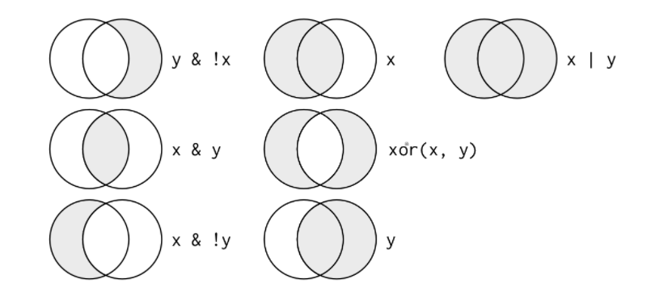

Consider the following examples:

- Pick observations from January and February
- Pick observations from January to April
- Pick observations NOT from January and February
- Pick observations on January 1st

These are just some simple examples, but once you understand these basics, you can easily execute complicated filter tasks to meet your research purposes in your research project.

### Missing Values

Missing value, or `NA`s (not available), can be common when carrying out a research project. If you want to decide if a value is missing, use `is.na()`. Another way (also an easier way) to find out if your dataset contain any missing value is using the `summary` function.

You can also filter out observations with missing values. For example, if you want to drop observations with departure time (`dep_time`) as missing values, run:

```r
filter(flights,is.na(dep_time)==FALSE)
```

```
## # A tibble: 328,521 x 19
##     year month   day dep_time sched_dep_time dep_delay arr_time sched_arr_time
##    <int> <int> <int>    <int>          <int>     <dbl>    <int>          <int>
##  1  2013     1     1      517            515         2      830            819
##  2  2013     1     1      533            529         4      850            830
##  3  2013     1     1      542            540         2      923            850
##  4  2013     1     1      544            545        -1     1004           1022
##  5  2013     1     1      554            600        -6      812            837
##  6  2013     1     1      554            558        -4      740            728
##  7  2013     1     1      555            600        -5      913            854
##  8  2013     1     1      557            600        -3      709            723
##  9  2013     1     1      557            600        -3      838            846
## 10  2013     1     1      558            600        -2      753            745
## # ... with 328,511 more rows, and 11 more variables: arr_delay <dbl>,
## #   carrier <chr>, flight <int>, tailnum <chr>, origin <chr>, dest <chr>,
## #   air_time <dbl>, distance <dbl>, hour <dbl>, minute <dbl>, time_hour <dttm>
```

## Arrange rows with `arrange()`

`arrange()` works similarly to `filter()` except that instead of selecting rows, it changes their order. It takes a data frame and a set of column names (or more complicated expressions) to order by. You can choose to rearrange rows by either ascending or descending order, and you can also reorder variables of different types, including numerical and categorical.

For example, if you want to re-order by departure delay in ascending order, run:

```r
arrange(flights,dep_delay)
```

```
## # A tibble: 336,776 x 19
##     year month   day dep_time sched_dep_time dep_delay arr_time sched_arr_time
##    <int> <int> <int>    <int>          <int>     <dbl>    <int>          <int>
##  1  2013    12     7     2040           2123       -43       40           2352
##  2  2013     2     3     2022           2055       -33     2240           2338
##  3  2013    11    10     1408           1440       -32     1549           1559
##  4  2013     1    11     1900           1930       -30     2233           2243
##  5  2013     1    29     1703           1730       -27     1947           1957
##  6  2013     8     9      729            755       -26     1002            955
##  7  2013    10    23     1907           1932       -25     2143           2143
##  8  2013     3    30     2030           2055       -25     2213           2250
##  9  2013     3     2     1431           1455       -24     1601           1631
## 10  2013     5     5      934            958       -24     1225           1309
## # ... with 336,766 more rows, and 11 more variables: arr_delay <dbl>,
## #   carrier <chr>, flight <int>, tailnum <chr>, origin <chr>, dest <chr>,
## #   air_time <dbl>, distance <dbl>, hour <dbl>, minute <dbl>, time_hour <dttm>
```

Similarly, if you want to re-order by departure delay in descending order, run:

```r
arrange(flights,desc(dep_delay))
```

```
## # A tibble: 336,776 x 19
##     year month   day dep_time sched_dep_time dep_delay arr_time sched_arr_time
##    <int> <int> <int>    <int>          <int>     <dbl>    <int>          <int>
##  1  2013     1     9      641            900      1301     1242           1530
##  2  2013     6    15     1432           1935      1137     1607           2120
##  3  2013     1    10     1121           1635      1126     1239           1810
##  4  2013     9    20     1139           1845      1014     1457           2210
##  5  2013     7    22      845           1600      1005     1044           1815
##  6  2013     4    10     1100           1900       960     1342           2211
##  7  2013     3    17     2321            810       911      135           1020
##  8  2013     6    27      959           1900       899     1236           2226
##  9  2013     7    22     2257            759       898      121           1026
## 10  2013    12     5      756           1700       896     1058           2020
## # ... with 336,766 more rows, and 11 more variables: arr_delay <dbl>,
## #   carrier <chr>, flight <int>, tailnum <chr>, origin <chr>, dest <chr>,
## #   air_time <dbl>, distance <dbl>, hour <dbl>, minute <dbl>, time_hour <dttm>
```

If you provide more than one column name, each additional column will be used to break ties in the values of preceding columns:

```r
arrange(flights,dep_delay,arr_delay)
```

```
## # A tibble: 336,776 x 19
##     year month   day dep_time sched_dep_time dep_delay arr_time sched_arr_time
##    <int> <int> <int>    <int>          <int>     <dbl>    <int>          <int>
##  1  2013    12     7     2040           2123       -43       40           2352
##  2  2013     2     3     2022           2055       -33     2240           2338
##  3  2013    11    10     1408           1440       -32     1549           1559
##  4  2013     1    11     1900           1930       -30     2233           2243
##  5  2013     1    29     1703           1730       -27     1947           1957
##  6  2013     8     9      729            755       -26     1002            955
##  7  2013     3    30     2030           2055       -25     2213           2250
##  8  2013    10    23     1907           1932       -25     2143           2143
##  9  2013     5     5      934            958       -24     1225           1309
## 10  2013     9    18     1631           1655       -24     1812           1845
## # ... with 336,766 more rows, and 11 more variables: arr_delay <dbl>,
## #   carrier <chr>, flight <int>, tailnum <chr>, origin <chr>, dest <chr>,
## #   air_time <dbl>, distance <dbl>, hour <dbl>, minute <dbl>, time_hour <dttm>
```

## Select Columns with `select()`

In a research project, it’s not uncommon to get a dataset with plenty of variables. However, due to your research purposes, you are usually only interested in a few subset of them.

In this case, the first challenge is often narrowing in on the variables you’re actually interested in. `select()` allows you to rapidly zoom in on a useful subset using operations based on the names of the variables.

`select()` is not terribly useful with our `flights` data because we only have 19 variables, but you can still get the general idea.

- Select columns by the names of the variables (`year`, `month`, and `day`):

```r
select(flights,year,month,day)
```

```
## # A tibble: 336,776 x 3
##     year month   day
##    <int> <int> <int>
##  1  2013     1     1
##  2  2013     1     1
##  3  2013     1     1
##  4  2013     1     1
##  5  2013     1     1
##  6  2013     1     1
##  7  2013     1     1
##  8  2013     1     1
##  9  2013     1     1
## 10  2013     1     1
## # ... with 336,766 more rows
```

- Select columns between variables `year` and `sched_dep_time`

```r
select(flights,year:sched_dep_time)
```

```
## # A tibble: 336,776 x 5
##     year month   day dep_time sched_dep_time
##    <int> <int> <int>    <int>          <int>
##  1  2013     1     1      517            515
##  2  2013     1     1      533            529
##  3  2013     1     1      542            540
##  4  2013     1     1      544            545
##  5  2013     1     1      554            600
##  6  2013     1     1      554            558
##  7  2013     1     1      555            600
##  8  2013     1     1      557            600
##  9  2013     1     1      557            600
## 10  2013     1     1      558            600
## # ... with 336,766 more rows
```

- Select columns except those between `year` and `sched_dep_time`

```r
select(flights,!(year:sched_dep_time))
```

```
## # A tibble: 336,776 x 14
##    dep_delay arr_time sched_arr_time arr_delay carrier flight tailnum origin
##        <dbl>    <int>          <int>     <dbl> <chr>    <int> <chr>   <chr>
##  1         2      830            819        11 UA        1545 N14228  EWR
##  2         4      850            830        20 UA        1714 N24211  LGA
##  3         2      923            850        33 AA        1141 N619AA  JFK
##  4        -1     1004           1022       -18 B6         725 N804JB  JFK
##  5        -6      812            837       -25 DL         461 N668DN  LGA
##  6        -4      740            728        12 UA        1696 N39463  EWR
##  7        -5      913            854        19 B6         507 N516JB  EWR
##  8        -3      709            723       -14 EV        5708 N829AS  LGA
##  9        -3      838            846        -8 B6          79 N593JB  JFK
## 10        -2      753            745         8 AA         301 N3ALAA  LGA
## # ... with 336,766 more rows, and 6 more variables: dest <chr>, air_time <dbl>,
## #   distance <dbl>, hour <dbl>, minute <dbl>, time_hour <dttm>
```

### Rename a variable’s name

`select()` can also be used to rename variables. For instance:

```r
select(flights, Year=year)
```

```
## # A tibble: 336,776 x 1
##     Year
##    <int>
##  1  2013
##  2  2013
##  3  2013
##  4  2013
##  5  2013
##  6  2013
##  7  2013
##  8  2013
##  9  2013
## 10  2013
## # ... with 336,766 more rows
```

However, it is rarely useful because `select()` drops all of the variables not explicitly mentioned.

Instead, use `rename()`, which is a variant of `select()` that keeps all the variables that aren’t explicitly mentioned:

```r
rename(flights,Year=year)
```

```
## # A tibble: 336,776 x 19
##     Year month   day dep_time sched_dep_time dep_delay arr_time sched_arr_time
##    <int> <int> <int>    <int>          <int>     <dbl>    <int>          <int>
##  1  2013     1     1      517            515         2      830            819
##  2  2013     1     1      533            529         4      850            830
##  3  2013     1     1      542            540         2      923            850
##  4  2013     1     1      544            545        -1     1004           1022
##  5  2013     1     1      554            600        -6      812            837
##  6  2013     1     1      554            558        -4      740            728
##  7  2013     1     1      555            600        -5      913            854
##  8  2013     1     1      557            600        -3      709            723
##  9  2013     1     1      557            600        -3      838            846
## 10  2013     1     1      558            600        -2      753            745
## # ... with 336,766 more rows, and 11 more variables: arr_delay <dbl>,
## #   carrier <chr>, flight <int>, tailnum <chr>, origin <chr>, dest <chr>,
## #   air_time <dbl>, distance <dbl>, hour <dbl>, minute <dbl>, time_hour <dttm>
```

### The `everything()` Helper

Another option is to use `select()` in conjunction with the `everything()` helper. This is useful if you have a handful of variables you’d like to move to the start of the data frame. For example:

```r
select(flights, carrier, air_time, everything())
```

```
## # A tibble: 336,776 x 19
##    carrier air_time  year month   day dep_time sched_dep_time dep_delay arr_time
##    <chr>      <dbl> <int> <int> <int>    <int>          <int>     <dbl>    <int>
##  1 UA           227  2013     1     1      517            515         2      830
##  2 UA           227  2013     1     1      533            529         4      850
##  3 AA           160  2013     1     1      542            540         2      923
##  4 B6           183  2013     1     1      544            545        -1     1004
##  5 DL           116  2013     1     1      554            600        -6      812
##  6 UA           150  2013     1     1      554            558        -4      740
##  7 B6           158  2013     1     1      555            600        -5      913
##  8 EV            53  2013     1     1      557            600        -3      709
##  9 B6           140  2013     1     1      557            600        -3      838
## 10 AA           138  2013     1     1      558            600        -2      753
## # ... with 336,766 more rows, and 10 more variables: sched_arr_time <int>,
## #   arr_delay <dbl>, flight <int>, tailnum <chr>, origin <chr>, dest <chr>,
## #   distance <dbl>, hour <dbl>, minute <dbl>, time_hour <dttm>
```

## Add New Variables with `mutate()`

In a research project, besides selecting sets of existing columns with `select()`, it’s often useful to add new columns that are functions of existing columns. That’s the job of `mutate()`. `mutate()` always adds new columns at the end of your dataset.

Suppose we want to create a new variable the represents the difference between `dep_delay` and `arr_delay` called `gain` and another new variable that indicates the speed of the flight in miles per hour called `speed`, run:

```r
mutate(flights, gain = dep_delay - arr_delay,
       speed = (distance / air_time)*60)
```

```
## # A tibble: 336,776 x 21
##     year month   day dep_time sched_dep_time dep_delay arr_time sched_arr_time
##    <int> <int> <int>    <int>          <int>     <dbl>    <int>          <int>
##  1  2013     1     1      517            515         2      830            819
##  2  2013     1     1      533            529         4      850            830
##  3  2013     1     1      542            540         2      923            850
##  4  2013     1     1      544            545        -1     1004           1022
##  5  2013     1     1      554            600        -6      812            837
##  6  2013     1     1      554            558        -4      740            728
##  7  2013     1     1      555            600        -5      913            854
##  8  2013     1     1      557            600        -3      709            723
##  9  2013     1     1      557            600        -3      838            846
## 10  2013     1     1      558            600        -2      753            745
## # ... with 336,766 more rows, and 13 more variables: arr_delay <dbl>,
## #   carrier <chr>, flight <int>, tailnum <chr>, origin <chr>, dest <chr>,
## #   air_time <dbl>, distance <dbl>, hour <dbl>, minute <dbl>, time_hour <dttm>,
## #   gain <dbl>, speed <dbl>
```

If you only want to keep the new variables, use `transmute()`, a variant of `mutate()` instead of `mutate()`:

```r
transmute(flights, gain = dep_delay - arr_delay,
       speed = (distance / air_time)*60)
```

```
## # A tibble: 336,776 x 2
##     gain speed
##    <dbl> <dbl>
##  1    -9  370.
##  2   -16  374.
##  3   -31  408.
##  4    17  517.
##  5    19  394.
##  6   -16  288.
##  7   -24  404.
##  8    11  259.
##  9     5  405.
## 10   -10  319.
## # ... with 336,766 more rows
```

Considering the following example:

- Create a new variable called `hours` to represent `air_time` in hour
- Create a new variable called `gain_per_hour` with `hours` and `gain` to represent a flight’s gain or loss in time per hour

### Useful Creation Functions

There are many functions for creating new variables that you can use with `mutate()`.

There is no way to list every possible function that you might use, but here is two functions that are frequently useful:

- Arithmetic operators: `+`, `-`, `*`, `/`, `^`. Arithmetic operators are also useful in conjunction with the aggregate functions. For example, `x / sum(x)` calculates the proportion of a total, and `y - mean(y)` computes the difference from the mean.
- Logs: `log()`, `log2()`, `log10()`. Logarithms are an incredibly useful transformation for dealing with data that ranges across multiple orders of magnitude.

Note that different creation functions can always be combined together.